# PSL Coding Assignment 1

### For PSL coding assignment 1, We are a team of 3 members and We three contributed to this project equally.

```python
import numpy as np
import pandas as pd
import matplotlib.pyplot as plt
from sklearn.neighbors import KNeighborsClassifier as knn

# Last 4 digits of Rui Zou's UIN
np.random.seed(5815)
```

## Data Generation

### Generate Centers

```python
p = 2
csize = 10
sigma = 1
m1 = np.random.normal(size = (csize, p)) * sigma + np.concatenate([np.array([[1, 0]] * csize)])
m0 = np.random.normal(size = (csize, p)) * sigma + np.concatenate([np.array([[0, 1]] * csize)])

class sim_params :
    csize = 10           # number of centers
    p = 2                # dimension
    s = np.sqrt(1 / 5)   # standard deviation for generating data
    n = 100              # training size per class
    N = 5000             # test size per class
    m0 = m0              # 10 centers for class 0
    m1 = m1              # 10 centers for class 1
```

### Generate Data

```python
def generate_sim_data(sim_params):

    p = sim_params.p
    s = sim_params.s
    n = sim_params.n
    N = sim_params.N
    m1 = sim_params.m1
    m0 = sim_params.m0
    csize = sim_params.csize

    id1 = np.random.randint(csize, size = n)
    id0 = np.random.randint(csize, size = n)

    Xtrain = np.random.normal(size = (2 * n, p)) * s \
                + np.concatenate([m1[id1,:], m0[id0,:]])
    Ytrain = np.concatenate(([1]*n, [0]*n))

    id1 = np.random.randint(csize, size = N)
    id0 = np.random.randint(csize, size = N)
    Xtest = np.random.normal(size = (2 * N, p)) * s \
                + np.concatenate([m1[id1,:], m0[id0,:]])
    Ytest = np.concatenate(([1]*N, [0]*N))

    return Xtrain, Ytrain, Xtest, Ytest
```

Use the function above to generate a set of training and test data.

```python
Xtrain, Ytrain, Xtest, Ytest = generate_sim_data(sim_params)
```

### Visualization

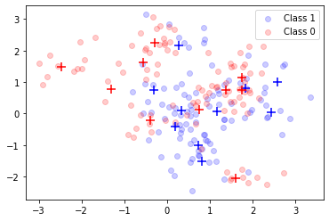

```python
n = sim_params.n
N = sim_params.N
m0 = sim_params.m0
m1 = sim_params.m1

plt.figure()
plt.scatter(Xtrain[:n, 0], Xtrain[:n, 1],
            color = 'blue', alpha = 0.2, label = 'Class 1')
plt.scatter(Xtrain[n:, 0], Xtrain[n:, 1],
            color = 'red', alpha = 0.2, label = 'Class 0')
plt.scatter(m1[:, 0], m1[:, 1], marker = '+', color = 'blue', s = 120)
plt.scatter(m0[:, 0], m0[:, 1], marker = '+', color = 'red', s = 120)
plt.legend()
plt.show()
```

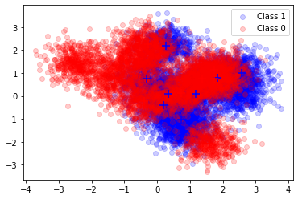

```python
plt.figure()
plt.scatter(Xtest[:N, 0], Xtest[:N, 1],
            color = 'blue', alpha = 0.2, label = 'Class 1')
plt.scatter(Xtest[N:, 0], Xtest[N:, 1],
            color = 'red', alpha = 0.2, label = 'Class 0')
plt.scatter(m1[:, 0], m1[:, 1], marker = '+', color = 'blue', s = 120)
plt.scatter(m0[:, 0], m0[:, 1], marker = '+', color = 'red', s = 120)
plt.legend()
plt.show()
```

## Part I: KNN

Compare your results with the ones from sklearn.neighbors.KNeighborsClassifier

```python
def confusion_matrix(Ytrue, Ypred):
    return np.bincount(Ytrue + 2*Ypred).reshape(2, 2)
```

```python
def knn_err(Xtrain, Xtest, Ytrain, Ytest, k):
    knn_model = knn(n_neighbors = k)
    knn_model.fit(Xtrain, Ytrain)
    test_pred = knn_model.predict(Xtest)
    err = np.mean(test_pred != Ytest)

    return test_pred, err
```

```python
knn_err(Xtrain, Xtest, Ytrain, Ytest, 1)[1], \
knn_err(Xtrain, Xtest, Ytrain, Ytest, 3)[1], \
knn_err(Xtrain, Xtest, Ytrain, Ytest, 5)[1]
```

```
(0.3059, 0.2758, 0.2722)
```

```python
confusion_matrix(Ytest, knn_err(Xtrain, Xtest, Ytrain, Ytest, 1)[0]) # same as pd.crosstab
```

```
array([[3350, 1409],
       [1650, 3591]])
```

```python
pd.crosstab(knn_err(Xtrain, Xtest, Ytrain, Ytest, 1)[0], Ytest)
```

| col_0 row_0 | 0 | 1 |
| --- | --- | --- |
| 0 | 3350 | 1409 |
| 1 | 1650 | 3591 |

```python
(1409 + 1650) / (2* sim_params.N)
```

```
0.3059
```

```python
# Euclidean Distance
# https://www.askpython.com/python/examples/k-nearest-neighbors-from-scratch
def eucledian(x, y):
    p = np.shape(x)[1]              # dimension of each vector, it's 2 here
    XX = np.multiply(x, x)
    YY = np.multiply(y, y)          # element-wise multiplication for x and y
    XY = np.dot(x, y.transpose())   # dot product here
    dist = np.add.outer(np.dot(XX, np.ones(p)), np.dot(YY, np.ones(p))) - 2*XY  # use outer sum
    return dist
```

```python
# Check for Euclidean distance (squared):
xx = np.array([[1,0], [0,1], [0,0]])
yy = np.array([[1,1], [2,1]])
distance = eucledian(xx, yy)
print(np.shape(distance))
print(distance)
print(distance.transpose())
```

```
(3, 2)
[[1. 2.]
 [1. 4.]
 [2. 5.]]
[[1. 1. 2.]
 [2. 4. 5.]]
```

```python
def my_knn(Xtrain, Xtest, Ytrain, k):
    # calculate the distance between xtest and xtrain:
    distance = eucledian(Xtrain, Xtest)              # a n*N matrix
    indices = np.argsort(distance.transpose())       # sort the distance, get indices
    #### using python's argsort, it gives the first index first if two or more values are equal
    indices_k = indices.transpose()[:k, :]           # first K smallest distance

    N = np.shape(Xtest)[0]                           # number of test data
    y_knn = np.zeros((k, N))
    votes = [0]*N
    y_pred = [0]*N

    for j in range(N):
        y_knn[:, j] = Ytrain[indices_k[:, j]]       # y for k-closest training data
        votes[j] = sum(y_knn[:, j])
        if votes[j] > k/2:
            y_pred[j] = 1
        elif votes[j] < k/2:
            y_pred[j] = 0
        else:    # voting tie, resort to (K+1)-th distance for result -- seems more reasonable than a random assignment:
                 # alternatively, delete the K-th element, rely on (K-1) nearest elements only
            y_pred[j] = Ytrain[indices[j, k]]

    return np.array(y_pred)
```

Distance ties: It's possible that k and k+1 have the same distances. np.argsort will sort the indices from low to high. So when k and k+1 have equal distances, the smaller index will be chosen. Note that when the order of indices in the dataset has a meaning, e.g., men are put in the first half of the data and women are put in the second half of the data, the algorithm will always choose men since their indices will be smaller when there are distance ties.

Voting ties: When k is an even number, it's possible that the top 2 clusters have the same data points. In this case, we bring in the (k+1)_th distance to break the tie.

```python
# k = 1: Confusion matrix from my KNN
test_pred = my_knn(Xtrain, Xtest, Ytrain, k = 1)
confusion_matrix(Ytest, test_pred)
```

```
array([[3350, 1409],
       [1650, 3591]])
```

```python
# k = 1: Confusion matrix from KNN package
confusion_matrix(Ytest, knn_err(Xtrain, Xtest, Ytrain, Ytest, 1)[0])
```

```
array([[3350, 1409],
       [1650, 3591]])
```

```python
# k = 3: Confusion matrix from my KNN
test_pred = my_knn(Xtrain, Xtest, Ytrain, k = 3)
confusion_matrix(Ytest, test_pred)
```

```
array([[3523, 1281],
       [1477, 3719]])
```

```python
# k = 3: Confusion matrix from KNN package
confusion_matrix(Ytest, knn_err(Xtrain, Xtest, Ytrain, Ytest, 3)[0])
```

```
array([[3523, 1281],
       [1477, 3719]])
```

```python
# k = 5: Confusion matrix from my KNN
test_pred = my_knn(Xtrain, Xtest, Ytrain, k = 5)
confusion_matrix(Ytest, test_pred)
```

```
array([[3591, 1313],
       [1409, 3687]])
```

```python
# k = 5: Confusion matrix from KNN package
confusion_matrix(Ytest, knn_err(Xtrain, Xtest, Ytrain, Ytest, 5)[0])
```

```
array([[3591, 1313],
       [1409, 3687]])
```

for K = 1, 3, 5, my KNN results match KNN pacakge.

## Part II: cv-KNN

Put sample code from the instructor into a function for computing CV error for a particular K value.

```python
def cal_error(k, n):
    err = 0

    indices = np.arange(n)
    np.random.shuffle(indices)
    index_sets = np.array_split(indices, num_folds)

    for ifold in range(num_folds):
        train_indices = np.delete(index_sets, obj=ifold, axis=0).ravel()
        _traindata = Xtrain[train_indices]
        _Ytrain = Ytrain[train_indices]

        test_indices = index_sets[ifold]
        _testdata = Xtrain[test_indices]
        _Ytest = Ytrain[test_indices]

        knn_model = knn(k)
        knn_model.fit(_traindata, _Ytrain)
        predict_Y = knn_model.predict(_testdata)
        err += sum(predict_Y != _Ytest)

    err /= float(n)

    return err
```

```python
def cvKNN(Xtrain, Ytrain, num_folds):
    n = len(Ytrain)
    fold_size = int(n / num_folds)
    kvector = range(1, n - fold_size)

    ########################################
    # Your Code
    # Compute CV errors and store them in k_cverr

    k_cverr = []

    for k in kvector:
        err = cal_error(k, n)
        k_cverr.append(err)

    #########################################

    tmp = np.column_stack((kvector, k_cverr))
    best_k = tmp[tmp[:,1] == np.min(tmp[:,1])][:,0]

    return int(np.max(best_k))
```

```python
num_folds = 10

best_k = cvKNN(Xtrain, Ytrain, num_folds)
cv_KNN = knn(best_k)
cv_KNN.fit(Xtrain, Ytrain)
test_pred = cv_KNN.predict(Xtest)
```

```python
confusion_matrix(Ytest, test_pred)
```

```
array([[3523, 1281],
       [1477, 3719]])
```

```python
pd.crosstab(test_pred, Ytest)
```

| col_0 row_0 | 0 | 1 |
| --- | --- | --- |
| 0 | 3523 | 1281 |
| 1 | 1477 | 3719 |

```python
np.mean(test_pred != Ytest)
```

```
0.2758
```

## Part III: Bayes Rule

```python
def bayesPredict(x, sim_params):
    s = sim_params.s
    m1 = sim_params.m1
    m0 = sim_params.m0

    d1 = sum(np.exp(- ((m1[i, 0] - x[:, 0]) ** 2 + (m1[i, 1] - x[:, 1]) ** 2) / (2 * s ** 2)) for i in range(len(m1)))
    d0 = sum(np.exp(- ((m0[i, 0] - x[:, 0]) ** 2 + (m0[i, 1] - x[:, 1]) ** 2) / (2 * s ** 2)) for i in range(len(m0)))

    y_pred = (d1 >= d0)

    return y_pred
```

```python
bayesPredict(Xtrain, sim_params)
```

```
array([False, False, False,  True,  True,  True,  True,  True,  True,
        True,  True,  True,  True,  True,  True,  True,  True,  True,
        True,  True,  True,  True,  True,  True,  True,  True,  True,
        True, False,  True,  True,  True,  True,  True, False,  True,
        True,  True, False,  True,  True,  True, False,  True,  True,
        True,  True,  True,  True,  True,  True,  True,  True,  True,
        True, False,  True, False,  True, False, False,  True,  True,
       False,  True,  True, False, False,  True,  True,  True,  True,
       False,  True,  True, False,  True,  True, False, False,  True,
        True,  True, False, False,  True,  True,  True,  True,  True,
       False,  True,  True,  True, False,  True,  True, False, False,
        True,  True, False, False, False,  True, False, False, False,
        True, False, False, False, False, False, False, False, False,
        True, False, False, False, False, False, False, False, False,
       False,  True, False,  True, False, False, False, False,  True,
       False, False, False,  True, False, False, False,  True, False,
       False, False, False,  True, False,  True, False, False, False,
       False, False, False, False, False, False, False, False, False,
       False, False,  True, False, False, False,  True, False, False,
       False, False, False, False, False, False,  True,  True, False,
       False, False,  True, False, False, False, False, False, False,
       False, False, False,  True,  True, False, False,  True, False,
       False, False])
```

## Part IV: Simulation Study

```python
def dataSimulation(M, sim_params):
    error_1 = [0]*M
    best_k = [0]*M
    error_best_k = [0]*M
    error_bayes = [0]*M

    for i in range(M):
        Xtrain, Ytrain, Xtest, Ytest = generate_sim_data(sim_params)

        # KNN classification with K=1:
        knn_1 = knn(n_neighbors = 1)
        knn_1.fit(Xtrain, Ytrain)
        test_pred = knn_1.predict(Xtest)
        error_1[i] = np.mean(test_pred != Ytest)

        # KNN classification with K chosen by 10-fold cross-validation:
        best_k[i] = cvKNN(Xtrain, Ytrain, 10)
        cv_KNN = knn(best_k[i])
        cv_KNN.fit(Xtrain, Ytrain)
        test_pred = cv_KNN.predict(Xtest)
        error_best_k[i] = np.mean(test_pred != Ytest)

        # the Bayes rule:
        test_pred = bayesPredict(Xtest, sim_params)
        error_bayes[i] = np.mean(test_pred != Ytest)

    return error_1, best_k, error_best_k, error_bayes
```

```python
error_1, best_k, error_best_k, error_bayes = dataSimulation(50, sim_params)
```

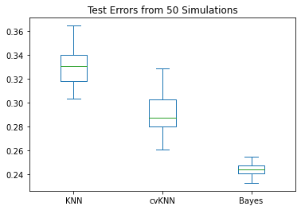

```python
data = pd.DataFrame({"KNN": error_1, "cvKNN": error_best_k, "Bayes": error_bayes})
ax = data.plot(kind='box', title='Test Errors from 50 Simulations')
plt.show()
```

```python
k_mean = np.mean(best_k)
k_std = np.std(best_k, ddof=1)

print(k_mean, k_std)
```

```
7.12 2.3702234459378446
```

Non-uniqueness of optimal k values in KNN: From the mean and standard error of the 50 k values, we can see that the optimal k value is not unique. We usually prefer to use larger k if we find several optimal k values, since larger k values give simpler models.